# Week2 Project

Patrick Ayer

6/9/2018

## Loading and preprocessing the data

Question 1:

```r
adata <- read.csv("activity.csv")
head(adata, n = 30)
```

```
##    steps       date interval
## 1     NA 2012-10-01        0
## 2     NA 2012-10-01        5
## 3     NA 2012-10-01       10
## 4     NA 2012-10-01       15
## 5     NA 2012-10-01       20
## 6     NA 2012-10-01       25
## 7     NA 2012-10-01       30
## 8     NA 2012-10-01       35
## 9     NA 2012-10-01       40
## 10    NA 2012-10-01       45
## 11    NA 2012-10-01       50
## 12    NA 2012-10-01       55
## 13    NA 2012-10-01      100
## 14    NA 2012-10-01      105
```

[output cut: 16 more lines]

Question 2: - remove the rows with missing values, as they won’t be needed - create new dataset of complete rows, stored in `ccdata` but keep original dataset

```r
ccdata <- adata[complete.cases(adata), ]
head(ccdata, n = 30)
```

```
##     steps       date interval
## 289     0 2012-10-02        0
## 290     0 2012-10-02        5
## 291     0 2012-10-02       10
## 292     0 2012-10-02       15
## 293     0 2012-10-02       20
## 294     0 2012-10-02       25
## 295     0 2012-10-02       30
## 296     0 2012-10-02       35
## 297     0 2012-10-02       40
## 298     0 2012-10-02       45
## 299     0 2012-10-02       50
## 300     0 2012-10-02       55
## 301     0 2012-10-02      100
## 302     0 2012-10-02      105
```

[output cut: 16 more lines]

## What is mean total number of steps taken per day?

Question 1:

```r
dates <- unique(as.factor(ccdata$date))
l <- length(dates)
total_steps <- vector("numeric", length = l)
for (i in 1:l)
{
    ddata <- ccdata[ccdata$date == as.character(dates[i]), ]
    total_steps[i] <- sum(ddata$steps)
}
head(total_steps, n = 30)
```

```
##  [1]   126 11352 12116 13294 15420 11015 12811  9900 10304 17382 12426
## [12] 15098 10139 15084 13452 10056 11829 10395  8821 13460  8918  8355
## [23]  2492  6778 10119 11458  5018  9819 15414 10600
```

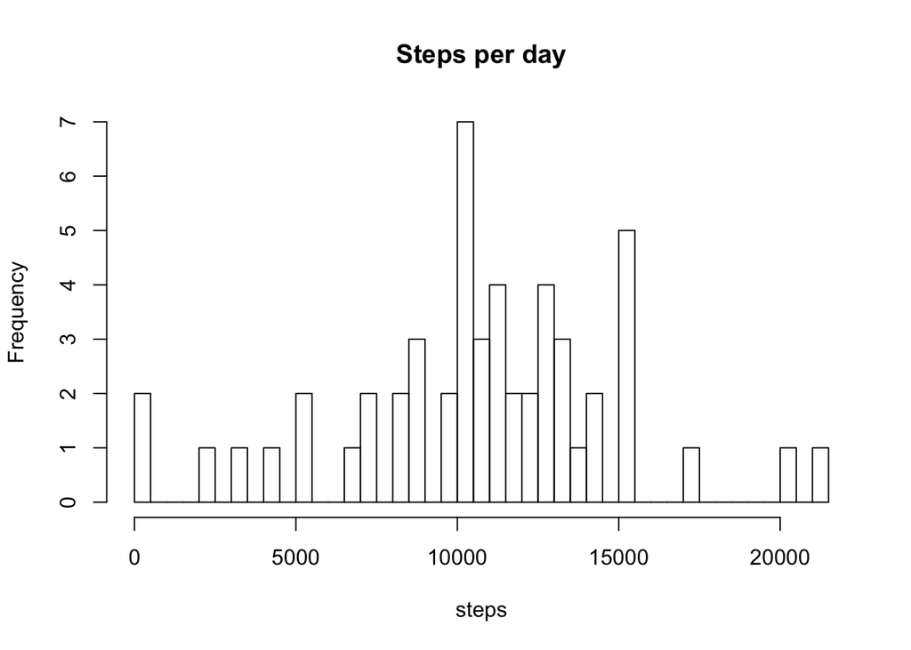

```r
hist(total_steps, breaks = l, xlab = "steps", main = "Steps per day")
```

Question 2: mean and median total steps taken per day:

```r
print(paste("Mean is ", mean(total_steps)), sep = "")
```

```
## [1] "Mean is  10766.1886792453"
```

```r
print(paste("Median is ", median(total_steps)), sep = "")
```

```
## [1] "Median is  10765"
```

## What is the average daily activity pattern?

Question 1:

```r
intervals <- unique(as.factor(ccdata$interval))
averages <- vector("numeric", length = length(intervals))
max_avg <- 0
max_interval <- 0
for (i in 1:length(intervals))
{
    idata <- ccdata[ccdata$interval == as.character(intervals[i]), ]
    averages[i] <- mean(idata$steps)
    if (averages[i] > max_avg)
    {
        max_avg <- averages[i]
        max_interval <- intervals[i]
    }
}
head(averages, n = 20)
```

```
##  [1] 1.7169811 0.3396226 0.1320755 0.1509434 0.0754717 2.0943396 0.5283019
##  [8] 0.8679245 0.0000000 1.4716981 0.3018868 0.1320755 0.3207547 0.6792453
## [15] 0.1509434 0.3396226 0.0000000 1.1132075 1.8301887 0.1698113
```

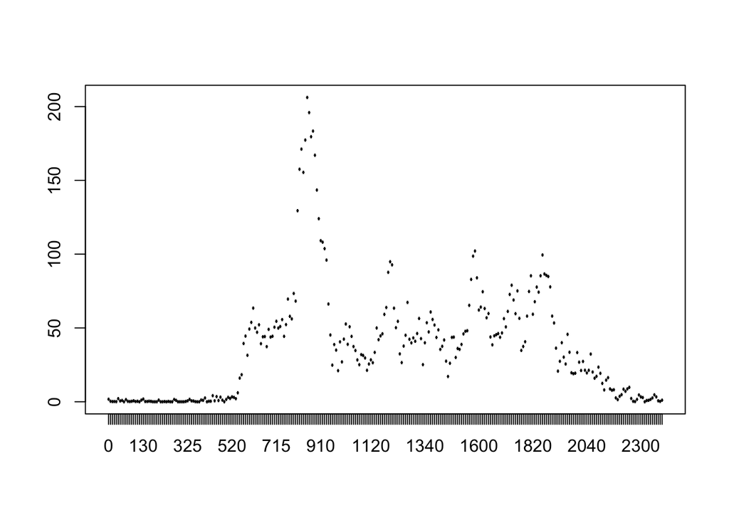

```r
plot(intervals, averages, type = "l")
```

```r
max_avg
```

```
## [1] 206.1698
```

```r
as.integer(as.character(max_interval))
```

```
## [1] 835
```

Question 2: the 5-minute interval with the maximum number of steps, on average, is the interval 835, with a value of 206.1698113

## Imputing missing values

Question 1: the total number of missing values is 2304 Question 2 & 3: the strategy I will use in filling in the missing data is by replacing all NA values with the means for that time interval

```r
for (n in 1:nrow(adata))
{
    if (is.na(adata[n, 1]))
    {
        this_i <- adata[n, 3]
        for (i in 1:length(intervals))
        {
            if (intervals[i] == this_i)
            {
                adata[n, 1] <- averages[i]
            }
        }
    }
}
head(adata, n = 30)
```

```
##        steps       date interval
## 1  1.7169811 2012-10-01        0
## 2  0.3396226 2012-10-01        5
## 3  0.1320755 2012-10-01       10
## 4  0.1509434 2012-10-01       15
## 5  0.0754717 2012-10-01       20
## 6  2.0943396 2012-10-01       25
## 7  0.5283019 2012-10-01       30
## 8  0.8679245 2012-10-01       35
## 9  0.0000000 2012-10-01       40
## 10 1.4716981 2012-10-01       45
## 11 0.3018868 2012-10-01       50
## 12 0.1320755 2012-10-01       55
## 13 0.3207547 2012-10-01      100
## 14 0.6792453 2012-10-01      105
```

[output cut: 16 more lines]

Question 4: histogram of total steps per day

```r
dates <- unique(as.factor(adata$date))
l <- length(dates)
total_steps <- vector("numeric", length = l)
head(total_steps, n = 10)
```

```
##  [1] 0 0 0 0 0 0 0 0 0 0
```

```r
for (i in 1:l)
{
    ddata <- adata[adata$date == as.character(dates[i]), ]
    total_steps[i] <- sum(ddata$steps)
}
head(total_steps, n = 30)
```

```
##  [1] 10766.19   126.00 11352.00 12116.00 13294.00 15420.00 11015.00
##  [8] 10766.19 12811.00  9900.00 10304.00 17382.00 12426.00 15098.00
## [15] 10139.00 15084.00 13452.00 10056.00 11829.00 10395.00  8821.00
## [22] 13460.00  8918.00  8355.00  2492.00  6778.00 10119.00 11458.00
## [29]  5018.00  9819.00
```

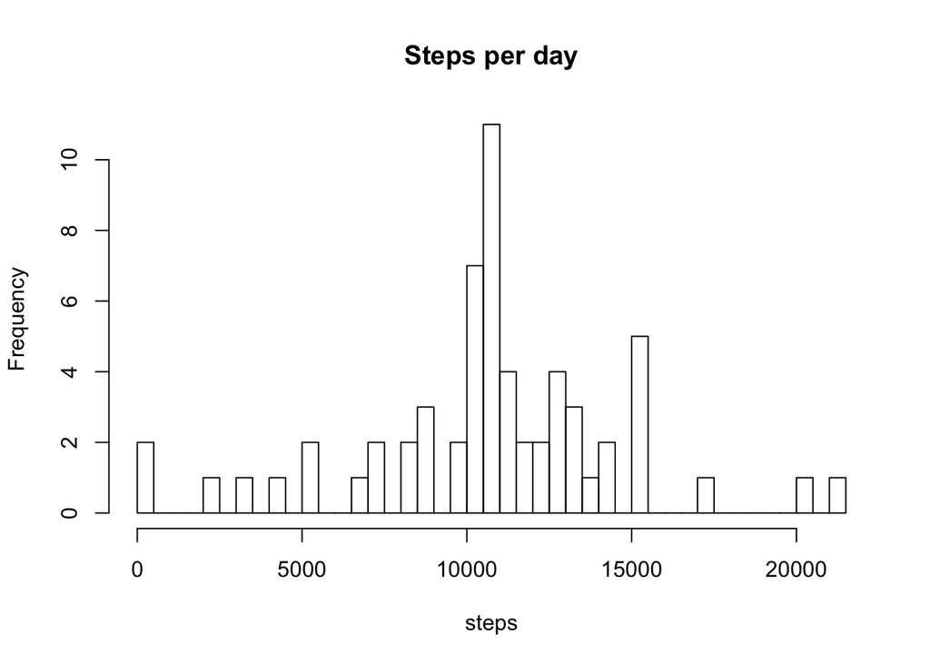

```r
hist(total_steps, breaks = l, xlab = "steps", main = "Steps per day")
```

mean and median total number of steps taken per day:

```r
print(paste("Mean is ", mean(total_steps)), sep = "")
```

```
## [1] "Mean is  10766.1886792453"
```

```r
print(paste("Median is ", median(total_steps)), sep = "")
```

```
## [1] "Median is  10766.1886792453"
```

It’s strange that these values are exactly the same, but they are very close to the original values with only the complete data set. The impact of estimating the missing values appears to be negligible.

## Are there differences in activity patterns between weekdays and weekends?

Question 1: below is the code chunk to create a new factor variable in the dataset to indicate weekends and weekdays:

```r
wdata <- ccdata
wdata$daytypes <- ""
for (i in 1:nrow(wdata))
{
    day <- weekdays(as.Date(wdata[i, 2]))
    if (day == "Saturday" | day == "Sunday")
    {
        wdata[i, 4] <- "weekend"
    }
    else
    {
        wdata[i, 4] <- "weekday"
    }
}

dweekdays <- wdata[wdata$daytypes == "weekday", ]
dweekends <- wdata[wdata$daytypes == "weekend", ]
head(dweekdays, n = 30)
```

```
##     steps       date interval daytypes
## 289     0 2012-10-02        0  weekday
## 290     0 2012-10-02        5  weekday
## 291     0 2012-10-02       10  weekday
## 292     0 2012-10-02       15  weekday
## 293     0 2012-10-02       20  weekday
## 294     0 2012-10-02       25  weekday
## 295     0 2012-10-02       30  weekday
## 296     0 2012-10-02       35  weekday
## 297     0 2012-10-02       40  weekday
## 298     0 2012-10-02       45  weekday
## 299     0 2012-10-02       50  weekday
## 300     0 2012-10-02       55  weekday
## 301     0 2012-10-02      100  weekday
## 302     0 2012-10-02      105  weekday
```

[output cut: 16 more lines]

```r
head(dweekends, n = 30)
```

```
##      steps       date interval daytypes
## 1441     0 2012-10-06        0  weekend
## 1442     0 2012-10-06        5  weekend
## 1443     0 2012-10-06       10  weekend
## 1444     0 2012-10-06       15  weekend
## 1445     0 2012-10-06       20  weekend
## 1446     0 2012-10-06       25  weekend
## 1447     0 2012-10-06       30  weekend
## 1448     0 2012-10-06       35  weekend
## 1449     0 2012-10-06       40  weekend
## 1450     0 2012-10-06       45  weekend
## 1451     0 2012-10-06       50  weekend
## 1452     0 2012-10-06       55  weekend
## 1453     0 2012-10-06      100  weekend
## 1454     0 2012-10-06      105  weekend
```

[output cut: 16 more lines]

Question 2: panel plot of time intervals and average steps taken.

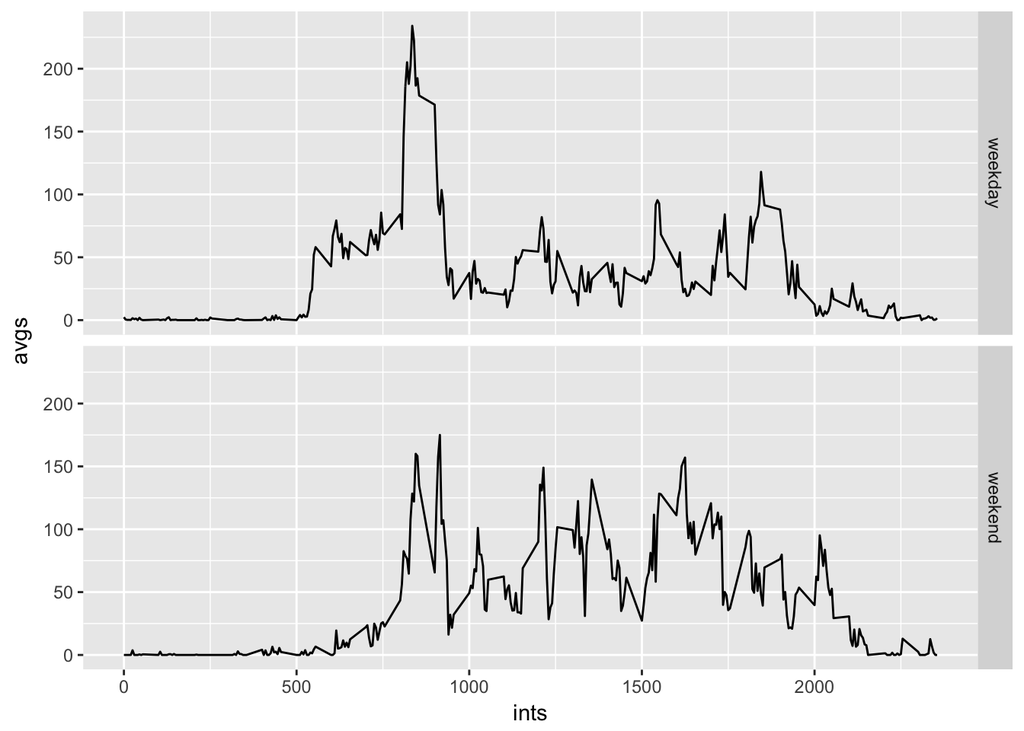

```r
ints <- unique(dweekdays$interval)
l <- length(ints)
avgs <- vector("numeric", length = l)
days <- rep("weekday", l)
for (i in 1:l)
{
    i_data <- dweekdays[dweekdays$interval == ints[i], ]
    avgs[i] <- mean(i_data$steps)
}
panel_data1 <- cbind(ints, avgs, days)

ints <- unique(dweekends$interval)
l <- length(ints)
avgs <- vector("numeric", length = l)
days <- rep("weekend", l)
for (i in 1:l)
{
    i_data <- dweekends[dweekends$interval == ints[i], ]
    avgs[i] <- mean(i_data$steps)
}
panel_data2 <- cbind(ints, avgs, days)

panel_data <- rbind(panel_data1, panel_data2)
panel_data <- data.frame(panel_data)
panel_data$avgs <- as.numeric(as.character(panel_data$avgs))
panel_data$ints <- as.integer(as.character(panel_data$ints))
panel_data$days <- as.factor(panel_data$days)

library(ggplot2)
sp <- ggplot(panel_data, aes(x = ints, y = avgs)) + geom_line() + facet_grid(days ~ .)
sp
```